# Introdução à séries temporais

Neuremberg de Matos

05/10/2020

## Objetivos

- Visão sobre o que são séries temporais: onde são encontradas, suas características e como trabalhar com elas no R.
- Visão geral sobre teste de quebras estrutural
- Visão geral sobre modelos suavização exponencial
- Visão geral sobre modelos Arima
- Como usar os scripts para gerar previsões para os dados de óbitos por *SRAG*.

## Passos Iniciais

### Series Temporais

- Conjunto de observações sobre um determinado fenômeno ordenados no tempo:

$$\{x_1, x_2, x_3, \dots, x_t, \dots, x_T\}$$

- As séries temporais possuem caracteríticas como nível, tendência e sazonalidade.
- O nível da série é o valor médio da série
- A tendência é como a série evolui ao longo do tempo. Isto é, se ela está crescendo, o caindo ao longo do tempo. Quando uma série não cresce ou diminuem ao longo, diz-se que ela não possui tendência.
- Dize-se que uma série possui comportamento sazonal quando em período cíclicos de tempo a série apresenta valores acima ou abaixo dos valores observados nos outros períodos de tempo. Por exemplo, vendas do comércio no período natalino.

Comportamento sazonal pode ser *aditivo* ou *multiplicativo*:

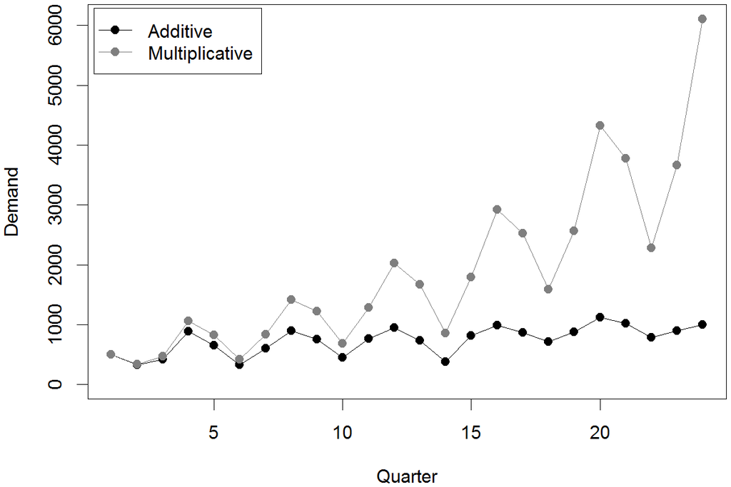

### Series temporais - Usando o R

Antes de iniciar a análise no no R, vamos carregar os pacotes que precisamos:

```r
library(dplyr)
library(lubridate)
library(ggplot2)
library(forecast)
```

Vamos usar o `dplyr` para manipular data frames, o `lubridate` para manipular data, os `ggplot2` para fazer alguns gráficos e o `forecast` para ajustar os modelos e fazer previsões.

E carregar algumas funções para nos ajudar:

```r
funcs <- new.env()
source("/src/funcoes.R", local = funcs, encoding = 'UTF-8')
```

Para os exemplos nessa apresentação, vamos usa o índice de produção industrial divulgado pelo IBGE. Vamos carregar do dados:

```r
path_data <- "../data/producao-industrial.csv"
dados <- read.csv2(file = path_data, stringsAsFactors = FALSE)
head(dados) %>%
  knitr::kable()
```

| periodo | indice |
| --- | --- |
| 01/01/2002 | 72.4 |
| 01/02/2002 | 69.7 |
| 01/03/2002 | 77.4 |
| 01/04/2002 | 79.6 |
| 01/05/2002 | 80.4 |
| 01/06/2002 | 77.5 |

Vamos transformar esses dados em uma série temporal no R:

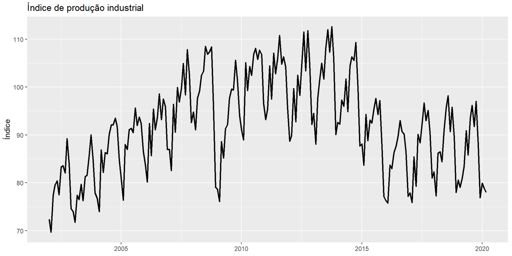

```r
produto <- ts(
  data = dados$indice, start = c(2002, 1), frequency = 12
)
autoplot(produto, size = .9) +
  labs(
    x = NULL, y = 'Índice', title = 'Índice de produção industrial'
  )
```

Decompondo a série temporal em seus componentes:

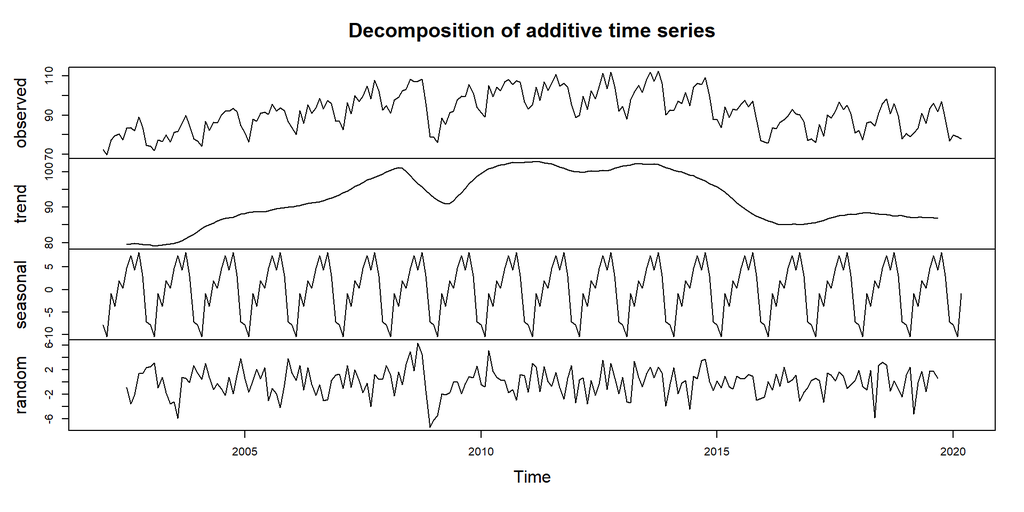

```r
dec <- decompose(produto)
plot(dec)
```

## Suavização exponencial

### SES

- Os modelos se suavização exponencial *Holt* e *Holt-Winters* são evoluções a partir do modelo do modelo de Suavização Exponencial Simples - *SES*.
- Esse modelo atribui diferentes pessos para cada observação da série para realizar previsões.
- Esses pesos decrescem exponencialmente a medida que as observações são mais antigas. Essa ideia é formulada por meio da equação:

$$\hat{y}_{T+1|T} = \alpha y_T + \alpha(1- \alpha)y_{T-1} + \alpha(1 - \alpha)^2 y_{T-2} + \dots$$
- Sendo $0 \leq \alpha \leq 1$ o parâmetro de suavização para o nível da série.

- O termo $(1-\alpha)$ é menor que $1$ para valores $0<\alpha<1$, isso faz com que os pesos dados às observações decresçam exponencialmente a medida que a potência de $(1-\alpha)$ aumenta.
- O modelo *SES* não é apropriado para fazer previsões quando a série possui tendência.
- Um modo de encontrar um $\alpha$ apropriado é encontrar um $\alpha$ que minimize a soma dos resíduos do modelo de previsão.

$$\begin{equation}
SSE = \sum_{t=1}^{T}(y_t - \hat{y}_{t|t-1})^2
\end{equation}$$

- Uma forma alternativa para representar o SES é usar um sistema de equações de componentes. No caso, podemos representá-lo com uma equação de previsão e uma de suavização:

$$\begin{equation}
\begin{split}
\text{Equação de previsão:} &\ \hat{y}_{t+1|t} = l_t \\
\text{Equação de suavização:} &\ l_t = \alpha y_t + (1 - \alpha)l_{t-1}
\end{split}
\end{equation}$$

#### SES - Usando o R

```r
path_data <- "../data/variacao-mensal-ipca2.csv"
inf_mensal <- read.csv2(path_data, stringsAsFactors = FALSE)
head(inf_mensal) %>% knitr::kable()
```

| periodo | var_mensal |
| --- | --- |
| 01/2010 | 0.75 |
| 02/2010 | 0.78 |
| 03/2010 | 0.52 |
| 04/2010 | 0.57 |
| 05/2010 | 0.43 |
| 06/2010 | 0.00 |

Transformando os dados é uma série temporal:

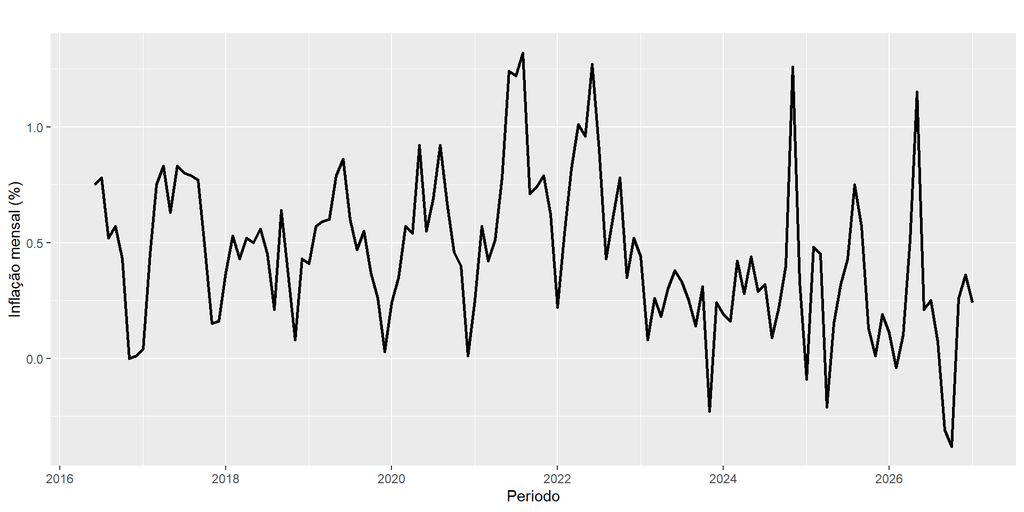

```r
inf_mensal <- ts(
  data = inf_mensal$var_mensal, start = c(2016, 06), frequency = 12
)

autoplot(inf_mensal, size = .9) +
  labs(x = 'Periodo', y = 'Inflação mensal (%)', size = .9)
```

Fazendo previsões com o SES:

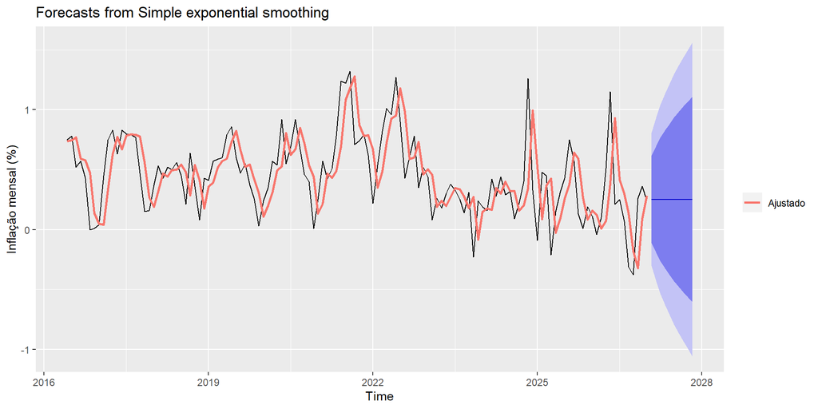

```r
model_ses <- ses(inf_mensal)

autoplot(model_ses, size = .9) +
  autolayer(fitted(model_ses), series = 'Ajustado', size = .9) +
  labs(y = 'Inflação mensal (%)', color = NULL)
```

### Holt

- O modelo SES não é apropriado para fazer previsões em séries com tendência. Por essa razão, Holt estendeu o modelo SES para ser usando com séries com tendência.
- Além de utilizar uma constante $\alpha$ para suavizar o valor médio, o modelo Holt utiliza uma outra constante $\beta$ para modelar atendência da série.
- O método Holt pode ser descrito por uma equação de previsão e duas equações de suavização:

$$\begin{equation}
\begin{split}
\text{Equação de previsão:} &\ \hat{y}_{t+h|t} = l_t + hb_t \\
\text{Equação de nível:} &\ l_t = \alpha y_t + (1-\alpha)(l_{t-1} + b_{t-1}) \\
\text{Equação de tendência:} &\ b_t = \beta(l_t - l_{t-1)} + (1- \beta)b_{t-1}
\end{split}
\end{equation}$$

#### Holt - Usando o R

Vamos carregar os dados sobre os óbitos por SRAG em Minas Gerais.

```r
srag_mg <- read.csv2(file = "../data/srag_mg.csv")
srag_mg <- srag_mg %>%
  mutate(dt_evoluca = ymd(dt_evoluca))

tail(srag_mg) %>% knitr::kable()
```

|  | sg_uf | dt_evoluca | obitos |
| --- | --- | --- | --- |
| 246 | MG | 2020-09-02 | 54 |
| 247 | MG | 2020-09-03 | 49 |
| 248 | MG | 2020-09-04 | 30 |
| 249 | MG | 2020-09-05 | 21 |
| 250 | MG | 2020-09-06 | 10 |
| 251 | MG | 2020-09-07 | 5 |

Plotando os dados segue:

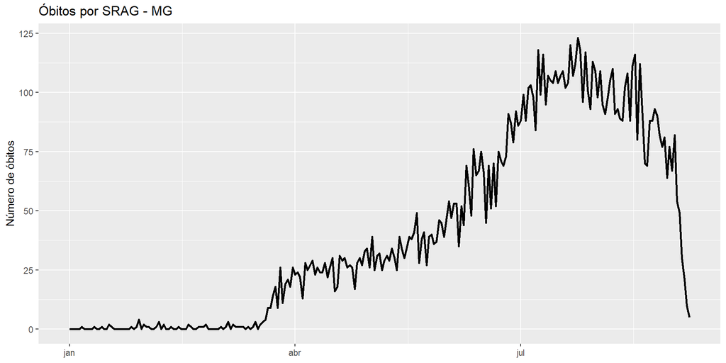

```r
funcs$plot_line(
  data = srag_mg, x = 'dt_evoluca', y = 'obitos',
  title = 'Óbitos por SRAG - MG'
)
```

Suavizando os dados com uma média móvel de 7 dias temos:

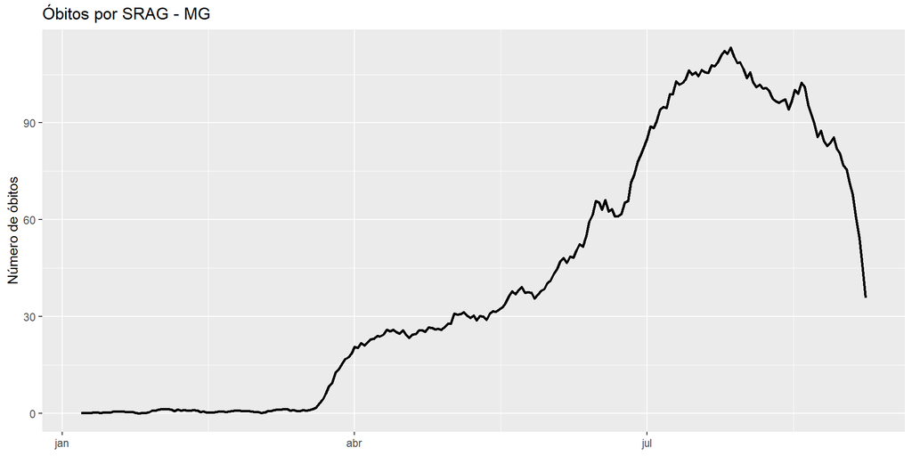

```r
srag_mg <- srag_mg %>%
  mutate(obitos = funcs$media_movel(obitos)) %>%
  filter(!is.na(obitos))

funcs$plot_line(
  data = srag_mg, x = 'dt_evoluca', y = 'obitos',
  title = 'Óbitos por SRAG - MG'
)
```

Vamos usar os dados até a data de 2020-08-14, onde foi deteminda uma quebra:

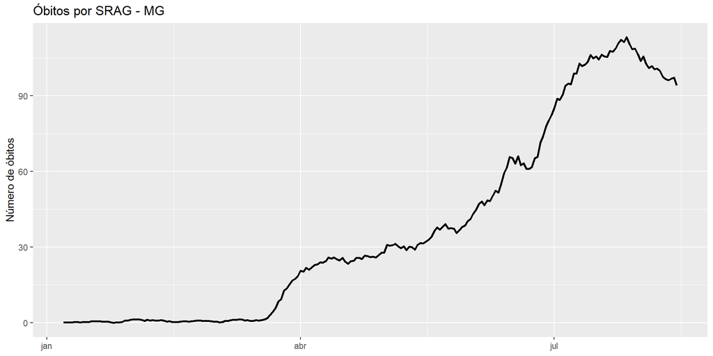

```r
srag_mg <- srag_mg %>%
  filter(dt_evoluca <= as.Date("2020-08-14"))

funcs$plot_line(
  data = srag_mg, x = 'dt_evoluca', y = 'obitos',
  title = 'Óbitos por SRAG - MG'
)
```

Vamos transformar os dados em série temporal fazer previsões:

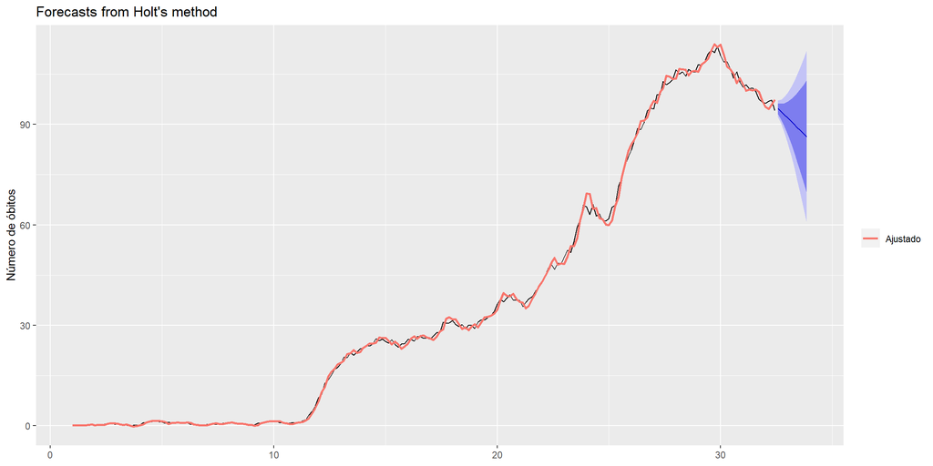

```r
obitos_mg <- ts(srag_mg$obitos, frequency = 7)
model_holt <- holt(y = obitos_mg)

autoplot(model_holt, size = .9) +
  autolayer(fitted(model_holt), series = 'Ajustado', size = .9) +
  labs(x = NULL, y = 'Número de óbitos', color = NULL)
```

Podemos obter as medidas de erro como:

```r
accuracy(model_holt) %>%
  knitr::kable()
```

|  | ME | RMSE | MAE | MPE | MAPE | MASE | ACF1 |
| --- | --- | --- | --- | --- | --- | --- | --- |
| Training set | -0.0082496 | 1.269052 | 0.8534525 | -Inf | Inf | 0.1942966 | -0.0109694 |

O *MAPE* assume o valor `Inf` quando há valores nulos na base. Dado que o *MAPE* é calculado como:

$$\begin{equation}
MAPE = \frac{1}{n}\sum_{t=1}^{n}\left|\frac{y_t - \hat{y}_t}{y_t}\right|
\end{equation}$$

E as previsões usando:

```r
forecast(model_holt) %>%
  as.data.frame() %>%
  head() %>%
  knitr::kable(row.names = FALSE, digits = 2)
```

| Point Forecast | Lo 80 | Hi 80 | Lo 95 | Hi 95 |
| --- | --- | --- | --- | --- |
| 94.70 | 93.06 | 96.35 | 92.19 | 97.21 |
| 93.77 | 91.38 | 96.16 | 90.12 | 97.43 |
| 92.84 | 89.32 | 96.37 | 87.45 | 98.24 |
| 91.91 | 86.98 | 96.84 | 84.37 | 99.45 |
| 90.98 | 84.44 | 97.52 | 80.98 | 100.98 |
| 90.05 | 81.73 | 98.37 | 77.33 | 102.77 |

### Holt-Winters

- Holt e Winters estenderam o modelo Holt para inclusão de sazonalidade.
- O modelo Holt-Winters é descrito por uma equação de previsão e três equações de suavização: Sendo uma equação para o nível $l_t$, uma equação para a tendência $b_t$ e uma equação para componente sazonal $s_t$, com os respectivos parâmetros de suavização $\alpha$, $\beta$ e $\gamma$.
- Como uma série temporal pode ter dois tipos de componente sazonal. Existe dois tipos de modelo Holt-Winters: Aditivo e o multiplicativo.
- As equações que descrevem o método Holt-Winter aditivo são:

$$\begin{equation}
\begin{split}
\hat{y}_{t+h|t} &= l_t + hb_t + s_{t+h-m(k+1)} \\
l_t &= \alpha(y_t - s_{t-m})+(1-\alpha)(l_{t-1} + b_{t-1}) \\
b_t &= \beta(l_t - l_{t-1}) + (1-\beta)b_{t-1} \\
s_t &= \gamma(y_t - l_{t-1} - b_{t-1}) + (1-\gamma)s_{t-m}
\end{split}
\end{equation}$$

- Já o Holt-Winters multiplicativo é descrito por:

$$\begin{equation}
\begin{split}
\hat{y}_{t+h|t} &= (l_t + hb_t)s_{t+h-m(k+1)} \\
l_t &= \alpha \frac{y_t}{s_{t-m}} + (1-\alpha)(l_{t-1} + b_{t-1}) \\
b_t &= \beta(l_t - l_{t-1}) + (1-\beta)b_{t-1} \\
s_t &= \gamma \frac{y_t}{(l_{t-1}+b_{t-1})} + (1-\gamma)s_{t-m}
\end{split}
\end{equation}$$

- Sendo $m$ a frequência da sazonalidade, para o caso de dados mensais $m=12$. E $k$ é a parte inteira de $(h-1)/m$.

#### Holt-Winters: Usando o R

Vamos ajustar o modelo Holt-Winters aditivo:

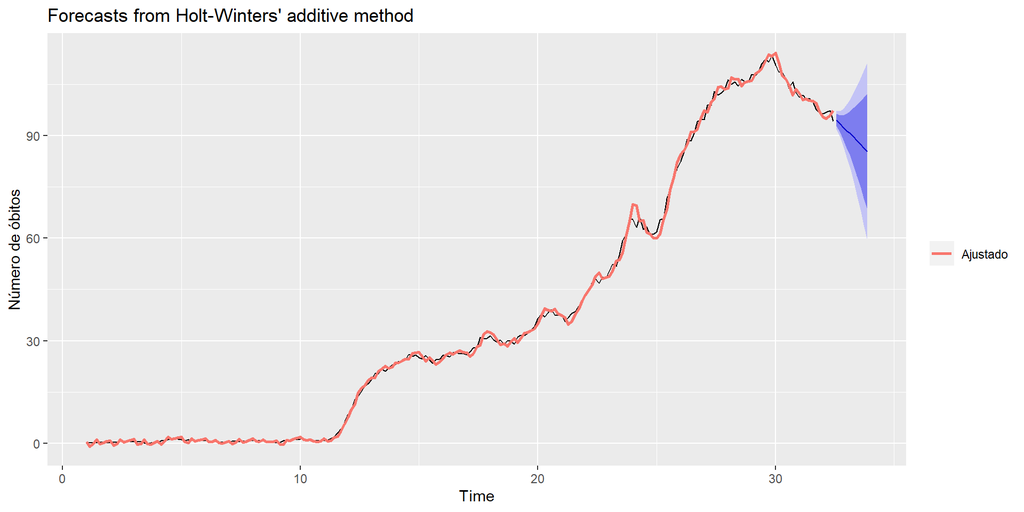

```r
model_hw_add <- hw(y = obitos_mg, h = 10, seasonal = 'additive')
autoplot(model_hw_add, size = .9) +
  autolayer(fitted(model_hw_add), series = 'Ajustado', size = .9) +
  labs(y = 'Número de óbitos', color = NULL)
```

Vamos ajustar o modelo Holt-Winters multiplicativo:

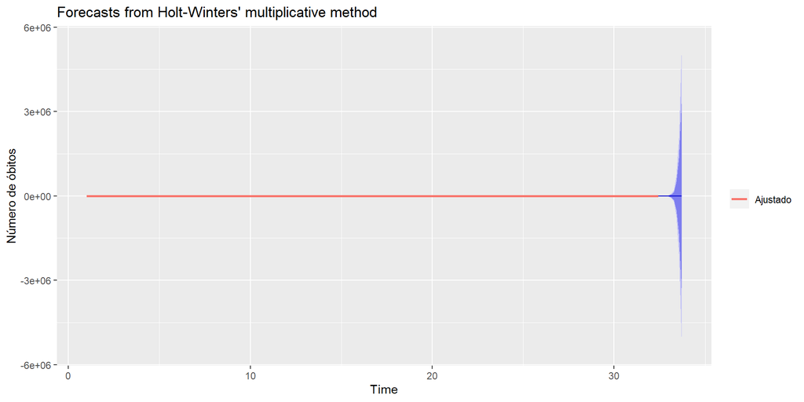

```r
obitos_mg_mod <- obitos_mg[obitos_mg > 0]
obitos_mg_mod <- ts(obitos_mg_mod, frequency = 7)

model_hw_mult <- hw(y = obitos_mg_mod, h = 10, seasonal = 'multiplicative')
autoplot(model_hw_mult, size = .9) +
  autolayer(fitted(model_hw_add), series = 'Ajustado', size = .9) +
  labs(y = 'Número de óbitos', color = NULL)
```

Comparando os erros de previsões entre os modelos estimados até aqui:

```r
erros <- rbind(
  accuracy(model_holt), accuracy(model_hw_add),
  accuracy(model_hw_mult)
)
erros <- data.frame(erros)
row.names(erros) <- c('Holt', 'HW-Aditivo', 'HW-Multiplicativo')

knitr::kable(erros, digits = 3)
```

|  | ME | RMSE | MAE | MPE | MAPE | MASE | ACF1 |
| --- | --- | --- | --- | --- | --- | --- | --- |
| Holt | -0.008 | 1.269 | 0.853 | -Inf | Inf | 0.194 | -0.011 |
| HW-Aditivo | -0.008 | 1.325 | 0.937 | Inf | Inf | 0.213 | 0.023 |
| HW-Multiplicativo | 0.021 | 1.493 | 1.048 | 5.649 | 16.299 | 0.238 | 0.090 |

Considerando o RMSE como métrica, o Holt foi o modelo que menos errou.

## Arima

### Arima

- o ARIMA *(Autoregressive Integrated Moving Average)* é um dos modelos mais utilizados para previsões de séries temporais.se
- Esse modelo foi desenvolvido nos anos 1970 por George Box e Gwilym Jenkins na tentativa de descrever as mudanças na série temporal.
- O modelo pode ser escrito da seguinte forma:

$$\begin{equation}
y_{t}^{\prime}=c+\phi_{1} y_{t-1}^{\prime}+\cdots+\phi_{p} y_{t-p}^{\prime}+\theta_{1} \varepsilon_{t-1}+\cdots+\theta_{q} \varepsilon_{t-q}+\varepsilon_{t}
\end{equation}$$

- Tal que, $y_{t}^{\prime}$ é a série diferenciada, $c$ é uma constante, e $\varepsilon_{t}$ é o erro.
- Um processo Arima é formado por dois outros processos: um processo autoregressivo (AR) e um processo de média móveis (MA). Além disso, uma ordem de integração.

### Processo Autoregressivo

- Um série temporal $y_t$ é um processo autoregressivo quando a observação no período $t$ da séries depende dos valores passados da série. Por exemplo

$$\begin{equation}
y_t = \mu + \alpha y_{t-1} + \varepsilon_t
\end{equation}$$

- Tal que o termo de erro possui um distribuição normal com média 0 e variância $\sigma_{\varepsilon}^2$, isto é, $\varepsilon_t \sim N(0,\sigma_{\varepsilon}^2)$
- A série acima é um processo regressivo de ordem 1. Um processo regressivo de ordem $p$ é dado por:

$$\begin{equation}
y_t = \mu + \alpha y_{t-1} + \alpha y_{t-1} + \dots + \alpha y_{t-p} + \varepsilon_t
\end{equation}$$

#### Processo Autoregressivo - Usando o R

No **R** podemos simular um processo regressivo da seguinte forma:

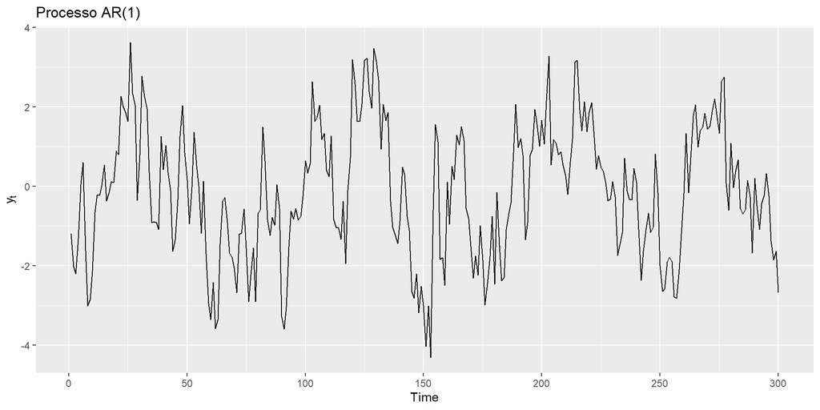

```r
set.seed(327)
ar1 <- arima.sim(model = list(ar = .8), n = 300)
autoplot(ar1) +
  labs(
    y = expression(paste(y[t])), title = 'Processo AR(1)'
    )
```

Nesse caso, simulamos um processo $AR(1)$ em que $\mu = 0$ e $\alpha_1 = 0,8$.

### Processo de média móveis

- Um processo $MA(1)$, isto é, um processo de médias móveis de ordem 1 pode ser caracterizado como:

$$\begin{equation}
y_t = \mu + \varepsilon_t + \theta\varepsilon_{t-1}
\end{equation}$$

- Em que $\varepsilon_t \sim N(0, \sigma_{\varepsilon}^2)$.
- Um processo de médias móveis de ordem $q$ pode ser caracterizado como:

$$\begin{equation}
y_t = \mu + \varepsilon_t + \theta_1\varepsilon_{t-1}+ \dots + \theta_q\varepsilon_{t-q}
\end{equation}$$

- Em um processo $MA$ o valor de $y_t$ é a média ponderada de erro aleatórios passados.

#### Processo de médias móveis - Usando o R

Podemos simular um processo de média móvel da seguinte forma:

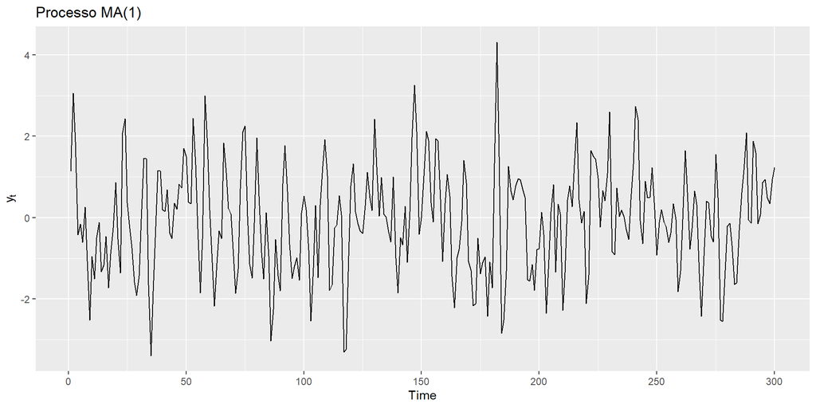

```r
set.seed(327)
ma1 <- arima.sim(model = list(ma = .8), n = 300)
autoplot(ma1) +
  labs(y = expression(paste(y[t])), title = 'Processo MA(1)')
```

Acima estamo simulando um processo $MA(1)$, em que $\theta_1 = 0,8$.